# Survival Analysis

## 3.3 - Graficzna prezentacjia funkcji skumulowanego hazardu dla wybranych zmiennych

- meno - Hazard jest zblżony dla obu grup pacjentek - przed menopazuą jak i po menopauzie - do około 1750 dnia. Od tego momentu znacznie wzrasta hazard dla pacjentek po menopauzie.
- grade - najwyższa wartość hazardu przypada dla pacjentek z guzem stopnia III, do około 2200 dnia - w tym momencie urywa się. Od tego momentu znacznie wzrasta hazard dla pacjentek z guzem stopnia II. Hazard dla pacjentek z guzem stopnia I zdecydowanie odstaje od pozostałych dwóch i jest najmniejszy.
- hormon - Hazard wzrasta szybciej dla pacjentek, które nie przechodzą terapii hormonalnej.Zmiana ta jest stała w czasie, jednak na końcu przedziału czasowego zdecydowanie wzrasta.

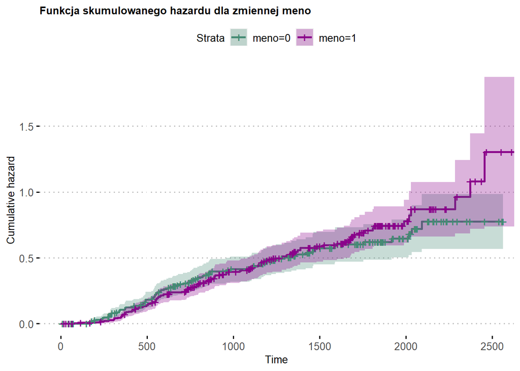

```r
ch1<-ggsurvplot(survfit(Surv(rfstime, cens) ~ meno, data = dane),
           conf.int = TRUE, ggtheme = theme_pubclean(), palette = c("aquamarine4", "darkmagenta"),
           title="Funkcja skumulowanego hazardu dla zmiennej meno",
           fun = "cumhaz")
ch2<-ggsurvplot(survfit(Surv(rfstime, cens) ~ grade, data = dane),
           conf.int = TRUE, ggtheme = theme_pubclean(), palette = c("cadetblue","burlywood4", "chartreuse4"),
           title="Funkcja skumulowanego hazardu dla zmiennej grade",
           fun = "cumhaz")
ch3<-ggsurvplot(survfit(Surv(rfstime, cens) ~ hormon, data = dane),
           conf.int = TRUE, ggtheme = theme_pubclean(), palette = c("cornsilk4", "cornflowerblue"),
           title="Funkcja skumulowanego hazardu dla zmiennej hormon",
           fun = "cumhaz")

ggpar(ch1, font.main = c(10, "bold"), font.x = c(10),font.y = c(10),font.caption = c(10),  font.legend = c(10),
      font.tickslab = c(10))
```

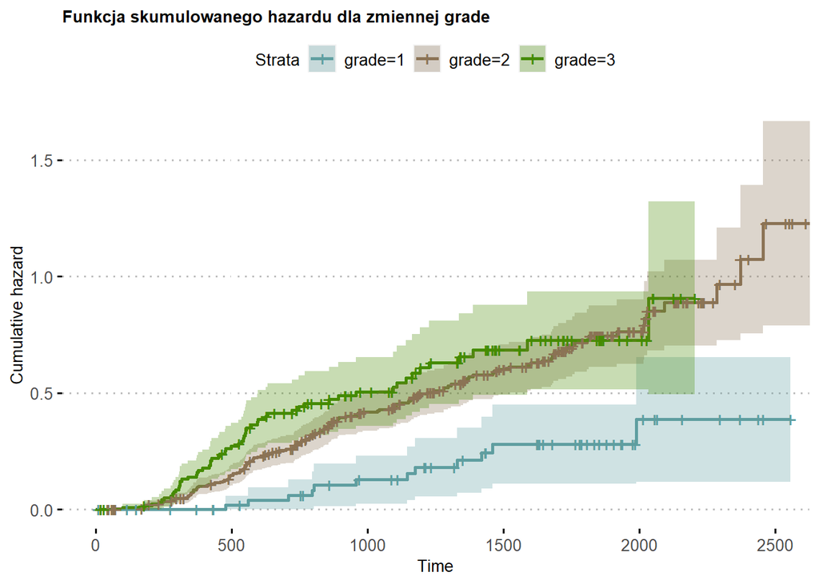

```r
ggpar(ch2, font.main = c(10, "bold"), font.x = c(10),font.y = c(10),font.caption = c(10),  font.legend = c(10),
      font.tickslab = c(10))
```

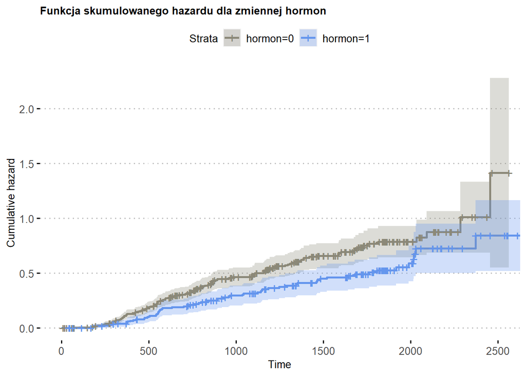

```r
ggpar(ch3, font.main = c(10, "bold"), font.x = c(10),font.y = c(10),font.caption = c(10),  font.legend = c(10),
      font.tickslab = c(10))
```

# 4 - Semiparametryczny model proporcjonalnego hazardu Coxa

Model Coxa generuje funkcję przeżycia przewidującą prawdopodobieństwo, że zdarzenie będące przedmiotem zainteresowania wystąpiło w określonym czasie (t) dla danych wartości zmiennych predyktora. Kształt funkcji przeżycia i współczynniki regresji dla predyktorów są szacowane na podstawie obserwowanych obiektów. Informacje z ocenzurowanych obiektów - które nie są przedmiotem zainteresowania podczas obserwacji, są równie przydatne podczas szacowania modelu.

## 4.1 - Estymacja modelu PH Coxa1 z wszystkimi zmiennymi objaśniającymi

Analizując poniższe wyniki testu Walda przynajmniej jedna zmienna objaśniająca w modelu statystycznie różni sie od 0. Zmienne grade, nodes, pgr oraz hormon są statystycznie różne od 0, ponieważ dla nich p-value < 0,05.

```r
Cox1 <- coxph(Surv(rfstime,cens)~age+meno+size+grade+nodes+pgr+er+hormon, data = dane)
summary(Cox1)
```

```
## Call:
## coxph(formula = Surv(rfstime, cens) ~ age + meno + size + grade +
##     nodes + pgr + er + hormon, data = dane)
##
##   n= 520, number of events= 223
##
##               coef  exp(coef)   se(coef)      z Pr(>|z|)
## age     -0.0110524  0.9890084  0.0111941 -0.987  0.32347
## meno1    0.1846363  1.2027809  0.2150645  0.859  0.39061
## size     0.0078595  1.0078905  0.0060782  1.293  0.19599
## grade2   0.7435714  2.1034344  0.3057524  2.432  0.01502 *
## grade3   0.7037387  2.0212956  0.3350722  2.100  0.03571 *
## nodes    0.1126442  1.1192337  0.0184940  6.091 1.12e-09 ***
## pgr     -0.0029864  0.9970181  0.0011072 -2.697  0.00699 **
## er       0.0000639  1.0000639  0.0012998  0.049  0.96079
## hormon1 -0.3671089  0.6927342  0.1523697 -2.409  0.01598 *
## ---
## Signif. codes:  0 '***' 0.001 '**' 0.01 '*' 0.05 '.' 0.1 ' ' 1
##
##         exp(coef) exp(-coef) lower .95 upper .95
## age        0.9890     1.0111    0.9675    1.0109
## meno1      1.2028     0.8314    0.7891    1.8334
## size       1.0079     0.9922    0.9960    1.0200
## grade2     2.1034     0.4754    1.1552    3.8299
## grade3     2.0213     0.4947    1.0481    3.8980
## nodes      1.1192     0.8935    1.0794    1.1605
## pgr        0.9970     1.0030    0.9949    0.9992
## er         1.0001     0.9999    0.9975    1.0026
## hormon1    0.6927     1.4436    0.5139    0.9338
##
## Concordance= 0.681  (se = 0.018 )
## Likelihood ratio test= 76.96  on 9 df,   p=6e-13
## Wald test            = 75.26  on 9 df,   p=1e-12
## Score (logrank) test = 80.56  on 9 df,   p=1e-13
```

## 4.2 - Zastosowanie funkcji krokowej (poszukuje ona najbardziej zoptymalizowanego ze wzgledu na kryterium AIC modelu) na podstawie modelu Cox1

Funkcja krokowa, na podstawie kryterium informacyjnego AIC, wskazała takie same zmienne do budowy modelu PH Coxa, jakie zostały uznane za statystycznie istotne od 0 na poziomie istotności 0.05 przy zastosowaniu testu Walda.

```r
stepAIC(Cox1,direction="backward")
```

```
## Start:  AIC=2488.71
## Surv(rfstime, cens) ~ age + meno + size + grade + nodes + pgr +
##     er + hormon
##
##          Df    AIC
## - er      1 2486.7
## - meno    1 2487.4
## - age     1 2487.7
## - size    1 2488.3
## <none>      2488.7
## - grade   2 2491.9
## - hormon  1 2492.7
## - pgr     1 2494.9
## - nodes   1 2519.9
##
## Step:  AIC=2486.71
## Surv(rfstime, cens) ~ age + meno + size + grade + nodes + pgr +
##     hormon
##
##          Df    AIC
## - meno    1 2485.5
## - age     1 2485.7
## - size    1 2486.4
## <none>      2486.7
## - grade   2 2489.9
## - hormon  1 2490.7
## - pgr     1 2494.0
## - nodes   1 2517.9
##
## Step:  AIC=2485.48
## Surv(rfstime, cens) ~ age + size + grade + nodes + pgr + hormon
##
##          Df    AIC
## - age     1 2483.7
## - size    1 2485.1
## <none>      2485.5
## - grade   2 2488.9
## - hormon  1 2489.1
## - pgr     1 2493.2
## - nodes   1 2517.2
##
## Step:  AIC=2483.72
## Surv(rfstime, cens) ~ size + grade + nodes + pgr + hormon
##
##          Df    AIC
## - size    1 2483.4
## <none>      2483.7
## - grade   2 2487.2
## - hormon  1 2488.2
## - pgr     1 2491.3
## - nodes   1 2515.3
##
## Step:  AIC=2483.39
## Surv(rfstime, cens) ~ grade + nodes + pgr + hormon
##
##          Df    AIC
## <none>      2483.4
## - grade   2 2486.9
## - hormon  1 2488.2
## - pgr     1 2490.8
## - nodes   1 2518.2
```

```
## Call:
## coxph(formula = Surv(rfstime, cens) ~ grade + nodes + pgr + hormon,
##     data = dane)
##
##              coef exp(coef)  se(coef)      z        p
## grade2   0.746975  2.110607  0.304360  2.454  0.01412
## grade3   0.756259  2.130293  0.330742  2.287  0.02222
## nodes    0.116604  1.123674  0.018136  6.429 1.28e-10
## pgr     -0.002999  0.997006  0.001040 -2.883  0.00393
## hormon1 -0.376485  0.686270  0.147435 -2.554  0.01066
##
## Likelihood ratio test=74.29  on 5 df, p=1.311e-14
## n= 520, number of events= 223
```

## 4.3 - Weryfikacja założenia proporcjonalności modelu PH Cox1

W celu poprawnego odzwzorowania wpływu zmiennych niezależnych na rozkład funkcji przeżycia jest spełnienie założenia proporcjonalności hazardów. Założenie jest spełnione dla zmiennej jeżeli p-value > 0,05. Dla zmiennych size, nodes, pgr oraz hormon założenie zostało spełnione, więc postanowiono użyć ich do budowy kolejnego modelu. Pomimo, że zmienna size nie jest statystycznie istotna od 0 oraz nie została wybrana podczas metody krokowej, postanowiono użyć jej do budowy kolejnego modelu - stworzonego na podstawie założenia proporcjonalności.

```r
Prop <- cox.zph(Cox1, transform = 'km')
print(Prop)
```

```
##         chisq df      p
## age     6.076  1 0.0137
## meno    3.903  1 0.0482
## size    0.199  1 0.6555
## grade   8.467  2 0.0145
## nodes   0.266  1 0.6058
## pgr     3.385  1 0.0658
## er      8.669  1 0.0032
## hormon  0.794  1 0.3729
## GLOBAL 18.265  9 0.0322
```

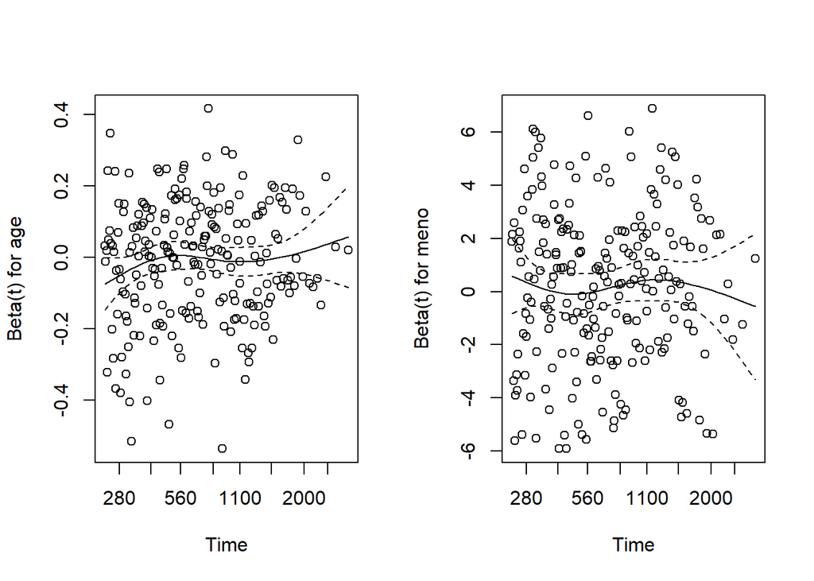

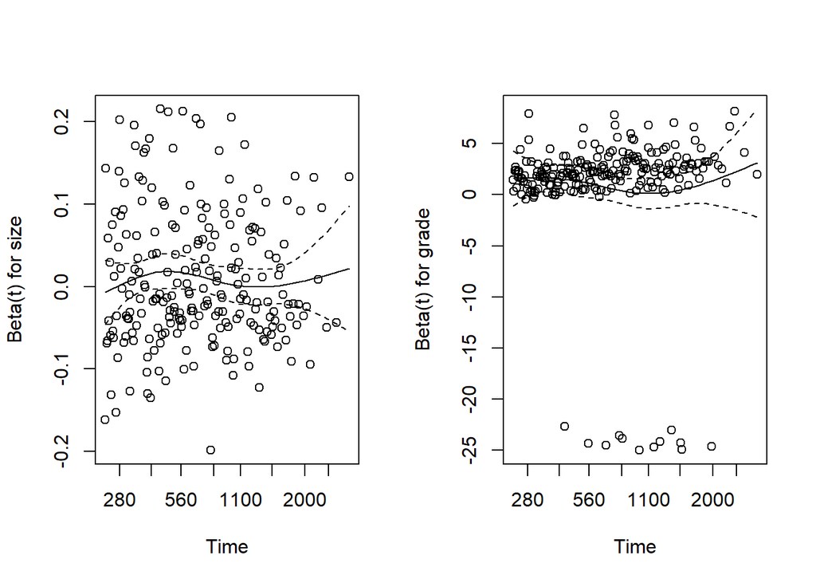

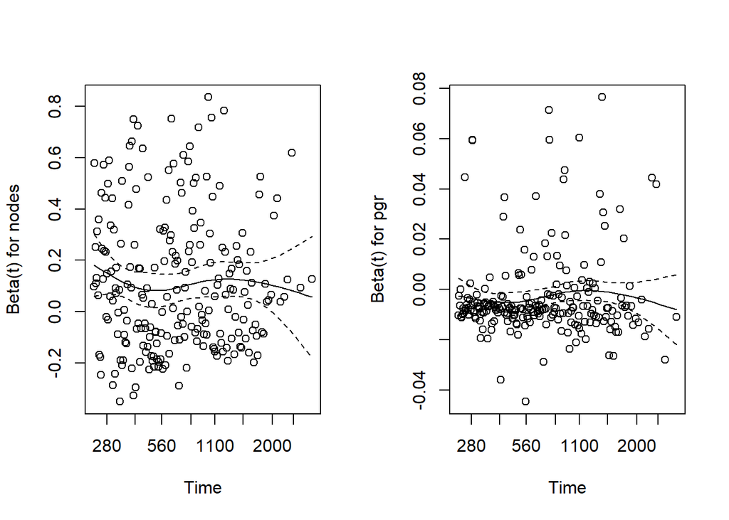

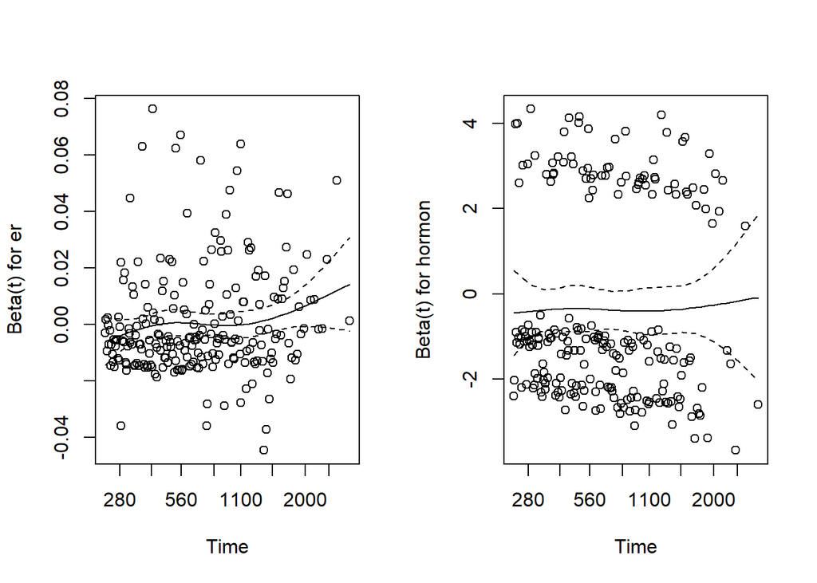

```r
par(mfrow=c(1,2))
plot(Prop)
```

## 4.4 - Estymacja nowego modelu Cox2

Estymacja modelu PH Coxa po odrzuceniu zmiennych nieistotnych statystycznie oraz zaproponowanych przez metodę krokową.

*Hazard określany jest jako ryzyko zgonu pod warunkiem, że jednostka dożyje do danego momentu.*

```r
Cox2 <- coxph(Surv(rfstime,cens)~grade+nodes+pgr+hormon, data = dane)
summary(Cox2)
```

```
## Call:
## coxph(formula = Surv(rfstime, cens) ~ grade + nodes + pgr + hormon,
##     data = dane)
##
##   n= 520, number of events= 223
##
##              coef exp(coef)  se(coef)      z Pr(>|z|)
## grade2   0.746975  2.110607  0.304360  2.454  0.01412 *
## grade3   0.756259  2.130293  0.330742  2.287  0.02222 *
## nodes    0.116604  1.123674  0.018136  6.429 1.28e-10 ***
## pgr     -0.002999  0.997006  0.001040 -2.883  0.00393 **
## hormon1 -0.376485  0.686270  0.147435 -2.554  0.01066 *
## ---
## Signif. codes:  0 '***' 0.001 '**' 0.01 '*' 0.05 '.' 0.1 ' ' 1
##
##         exp(coef) exp(-coef) lower .95 upper .95
## grade2     2.1106     0.4738     1.162    3.8325
## grade3     2.1303     0.4694     1.114    4.0735
## nodes      1.1237     0.8899     1.084    1.1643
## pgr        0.9970     1.0030     0.995    0.9990
## hormon1    0.6863     1.4572     0.514    0.9162
##
## Concordance= 0.673  (se = 0.018 )
## Likelihood ratio test= 74.29  on 5 df,   p=1e-14
## Wald test            = 72.91  on 5 df,   p=3e-14
## Score (logrank) test = 77.84  on 5 df,   p=2e-15
```

## 4.5 - Weryfikacja założenia proporcjonalności modelu Cox2

Zmienna grade nie spełnia założenia proporcjonalności, natomiast pozostałe zmienne spełniają założenie proporcjonalności.

```r
Prop <- cox.zph(Cox2, transform = 'km')
print(Prop)
```

```
##        chisq df     p
## grade  8.280  2 0.016
## nodes  0.234  1 0.629
## pgr    3.261  1 0.071
## hormon 0.759  1 0.384
## GLOBAL 9.882  5 0.079
```

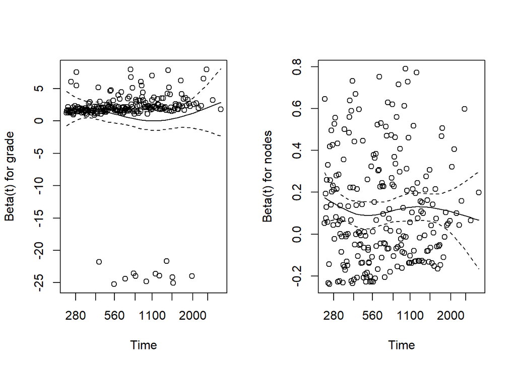

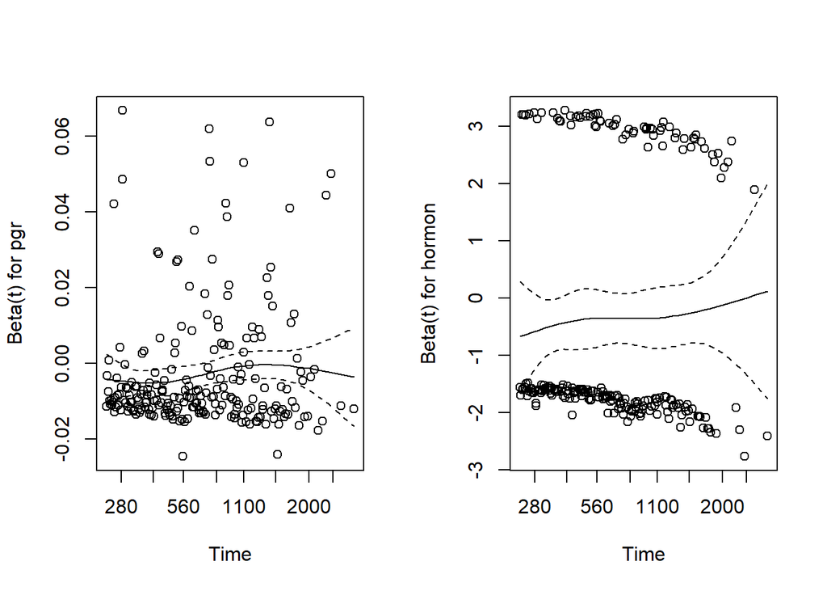

```r
par(mfrow=c(1,2))
plot(Prop)
```

## 4.6 - Estymacja modelu PH Coxa3 z wykorzystaniem zmiennych spełniających założenie o proporcjonalności

**Interpretacja parametrów:**

*Hazard określany jest jako ryzyko zgonu pod warunkiem, że jednostka dożyje do danego momentu.*

- Pacjentki, których rozmiar guza wzrośnie o 1 mm, to hazard wzrośnie o 0,79% cp.
- Jeżeli liczba węzłów chłonnych z przerzutami wzrośnie o 1, to hazard wzrośnie o 12,22% cp.
- Jeżeli poziom receptorów progesteronowych wzrośnie o 1 (fmol/l), to hazard zmaleje o 0,36% cp.
- Pacjentki, które przechodzą terapię hormonalną, mają hazard o 31,41% niższy niż pacjentki, które nie przechodzą terapii hormonalnej cp.

```r
Cox3 <- coxph(Surv(rfstime,cens)~size+nodes+pgr+hormon, data = dane)
summary(Cox3)
```

```
## Call:
## coxph(formula = Surv(rfstime, cens) ~ size + nodes + pgr + hormon,
##     data = dane)
##
##   n= 520, number of events= 223
##
##              coef exp(coef)  se(coef)      z Pr(>|z|)
## size     0.007820  1.007851  0.005914  1.322 0.186057
## nodes    0.115293  1.122203  0.018420  6.259 3.87e-10 ***
## pgr     -0.003628  0.996378  0.001010 -3.593 0.000327 ***
## hormon1 -0.377150  0.685813  0.146982 -2.566 0.010289 *
## ---
## Signif. codes:  0 '***' 0.001 '**' 0.01 '*' 0.05 '.' 0.1 ' ' 1
##
##         exp(coef) exp(-coef) lower .95 upper .95
## size       1.0079     0.9922    0.9962    1.0196
## nodes      1.1222     0.8911    1.0824    1.1635
## pgr        0.9964     1.0036    0.9944    0.9984
## hormon1    0.6858     1.4581    0.5142    0.9148
##
## Concordance= 0.673  (se = 0.018 )
## Likelihood ratio test= 68.5  on 4 df,   p=5e-14
## Wald test            = 70.12  on 4 df,   p=2e-14
## Score (logrank) test = 74.16  on 4 df,   p=3e-15
```

## 4.7 - Weryfikacja założenia proporcjonalności modelu Cox3

Wszystkie zmienne spełniają założenie proporcjonalności.

```r
Prop <- cox.zph(Cox3, transform = 'km')
print(Prop)
```

```
##        chisq df     p
## size   0.202  1 0.653
## nodes  0.255  1 0.614
## pgr    3.228  1 0.072
## hormon 0.942  1 0.332
## GLOBAL 4.193  4 0.380
```

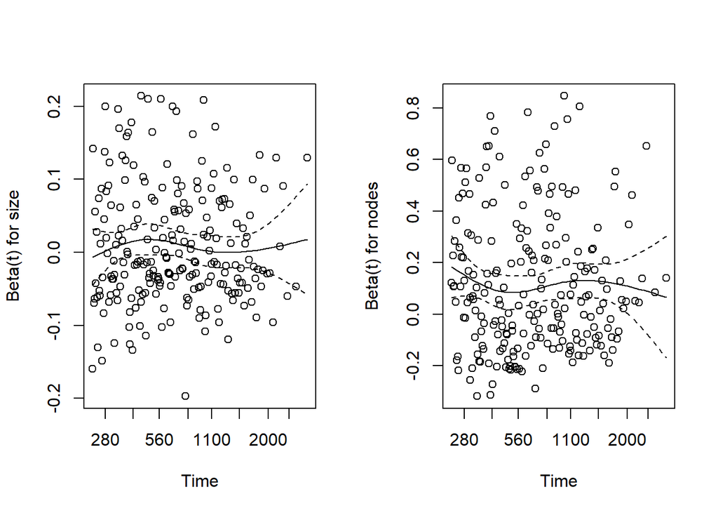

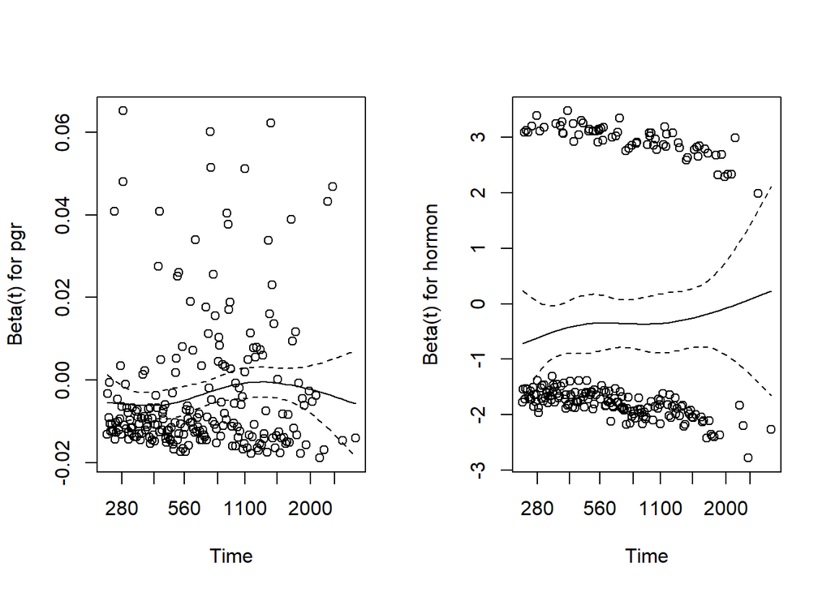

```r
par(mfrow=c(1,2))
plot(Prop)
```

## 4.8 - Estymacja modelu PH Coxa4 z wykorzystaniem zmiennych spełniających założenie o proporcjonalności oraz po odrzuceniu zmiennych nieistotnych statystycznie i zaproponowanych przez metodę krokową.

**Interpretacja parametrów:**

*Hazard określany jest jako ryzyko zgonu pod warunkiem, że jednostka dożyje do danego momentu.*

- Jeżeli liczba węzłów chłonnych z przerzutami wzrośnie o 1, to hazard wzrośnie o 12,59% cp.
- Jeżeli poziom receptorów progesteronowych wzrośnie o 1 (fmol/l), to hazard zmaleje o 0,36% cp.
- Pacjentki, które przechodzą terapię hormonalną, mają hazard o 32,05% niższy niż pacjentki, które nie przechodzą terapii hormonalnej cp.

```r
Cox4 <- coxph(Surv(rfstime,cens)~nodes+pgr+hormon, data = dane)
summary(Cox4)
```

```
## Call:
## coxph(formula = Surv(rfstime, cens) ~ nodes + pgr + hormon, data = dane)
##
##   n= 520, number of events= 223
##
##              coef exp(coef)  se(coef)      z Pr(>|z|)
## nodes    0.118555  1.125869  0.018107  6.548 5.85e-11 ***
## pgr     -0.003668  0.996339  0.001017 -3.607  0.00031 ***
## hormon1 -0.386443  0.679470  0.146806 -2.632  0.00848 **
## ---
## Signif. codes:  0 '***' 0.001 '**' 0.01 '*' 0.05 '.' 0.1 ' ' 1
##
##         exp(coef) exp(-coef) lower .95 upper .95
## nodes      1.1259     0.8882    1.0866    1.1665
## pgr        0.9963     1.0037    0.9944    0.9983
## hormon1    0.6795     1.4717    0.5096    0.9060
##
## Concordance= 0.67  (se = 0.018 )
## Likelihood ratio test= 66.79  on 3 df,   p=2e-14
## Wald test            = 68.6  on 3 df,   p=9e-15
## Score (logrank) test = 72.4  on 3 df,   p=1e-15
```

## 4.9 - Weryfikacja założenia proporcjonalności modelu Cox4

Wszystkie zmienne spełniają założenie proporcjonalności.

```r
Prop <- cox.zph(Cox4, transform = 'km')
print(Prop)
```

```
##        chisq df     p
## nodes  0.229  1 0.632
## pgr    3.360  1 0.067
## hormon 0.885  1 0.347
## GLOBAL 4.185  3 0.242
```

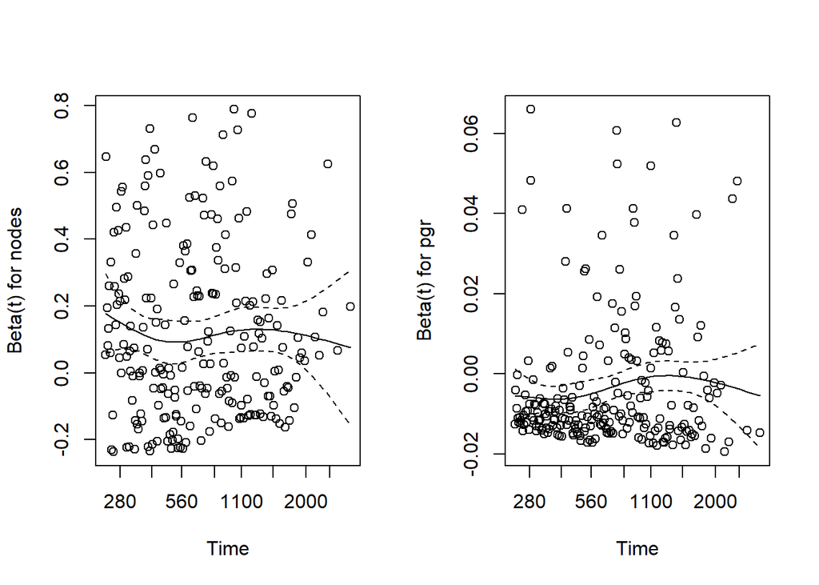

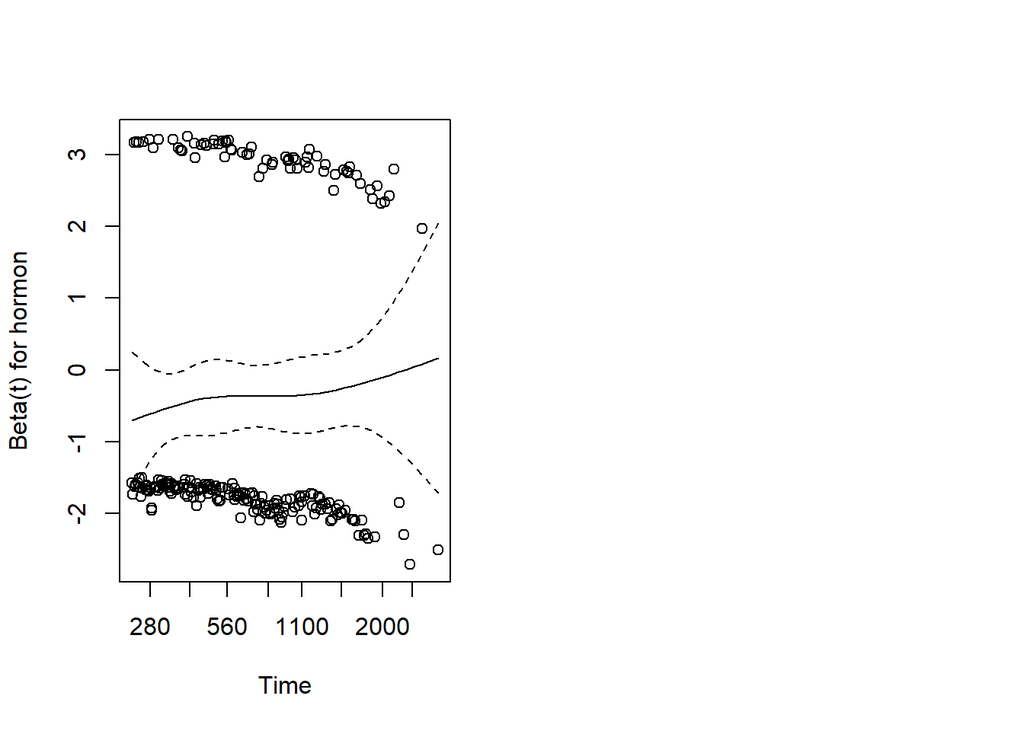

```r
par(mfrow=c(1,2))
plot(Prop)
```

## 4.10 - Identyfikacja jednostek odstających Cox2

Jednostki odstające/wpływowe mają nietypową konfigurację zmiennych objaśniających, a także mogą wywierać niepożądany wpływ na oszacowania parametrów i dopasowanie modelu.

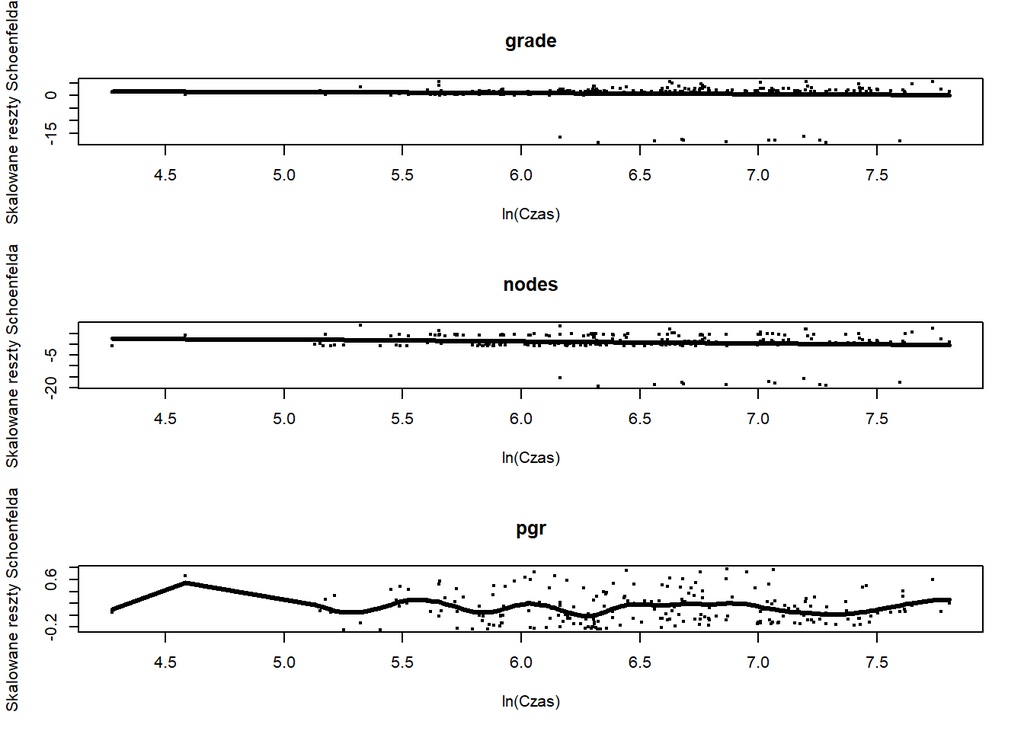

```r
reszty <- resid(Cox2, type="scaledsch")
Time <- as.numeric(rownames(reszty))
zmienne <- names(dane[,c(5,6,7,9)])

par(mfrow = c(3,1))
for (i in 1:4) {
  plot(log(Time), reszty[,i], xlab="ln(Czas)", main=zmienne[i],
       ylab="Skalowane reszty Schoenfelda", pch=20, cex=0.7)
  lines(smooth.spline(log(Time), reszty[,i] ), lwd=3 )
}
```

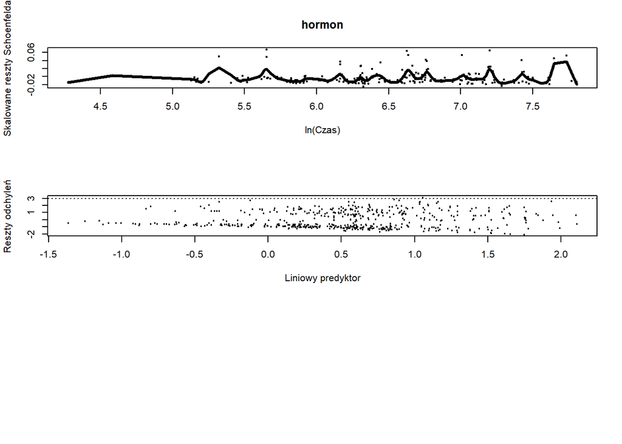

```r
deviance=residuals(Cox2,type="deviance")
s=Cox2$linear.predictors
plot(s,deviance,xlab="Liniowy predyktor",ylab="Reszty odchyleń",cex=0.5, pch=20)

abline(h=3,lty=3)
dane$deviance <- deviance
c1 <- which(dane$deviance > 3)
```

## 4.11 - Usuwanie ze zbioru jednostek odstających dla modelu Cox2

Jednostki o nietypowych/odstających parametrach, w miarę możliwości, powinny zostać usunięte ze zbioru.

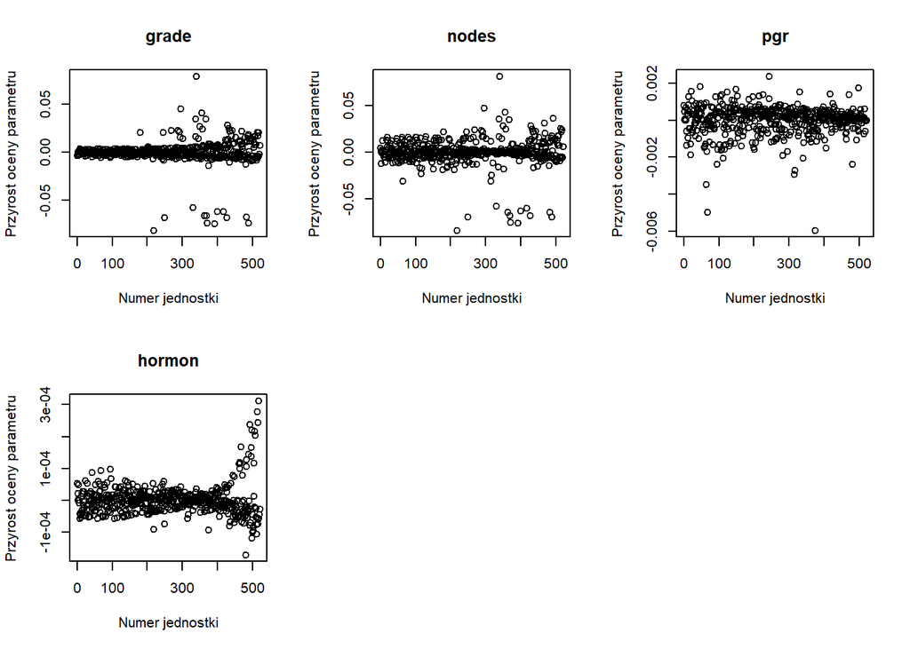

```r
dfb=residuals(Cox2,type="dfbeta")
n=dim(dfb)[1]
obs.nr=c(1:n)
par(mfrow = c(2,3))
for (j in 1:4) {
  plot(obs.nr,dfb[,j],xlab="Numer jednostki",ylab="Przyrost oceny parametru",
      main=zmienne[j])
  }
a1 = which(abs(dfb[,1])>(0.004)) #usunac te jednostki
a2 = which(abs(dfb[,2])>(0.01))
a3 = which(abs(dfb[,3])>(0.05))
a4 = which(abs(dfb[,4])>(0.004))

c <- sort(unique(c(a1,a2,a3,a4,c1)))
danec1 <- dane[-c,]
```

## 4.12 - Identyfikacja jednostek odstających Cox3

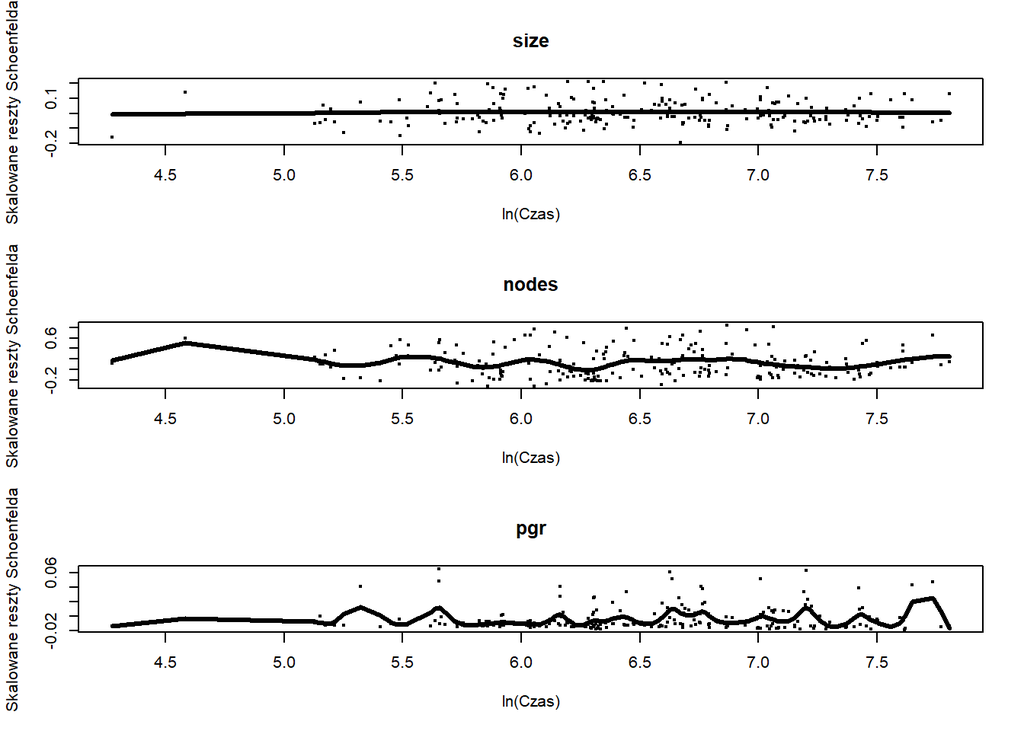

```r
reszty <- resid(Cox3, type="scaledsch")
Time <- as.numeric(rownames(reszty))
zmienne <- names(dane[,c(4,6,7,9)])

par(mfrow = c(3,1))
for (i in 1:4) {
  plot(log(Time), reszty[,i], xlab="ln(Czas)", main=zmienne[i],
       ylab="Skalowane reszty Schoenfelda", pch=20, cex=0.7)
  lines(smooth.spline(log(Time), reszty[,i] ), lwd=3 )
}
```

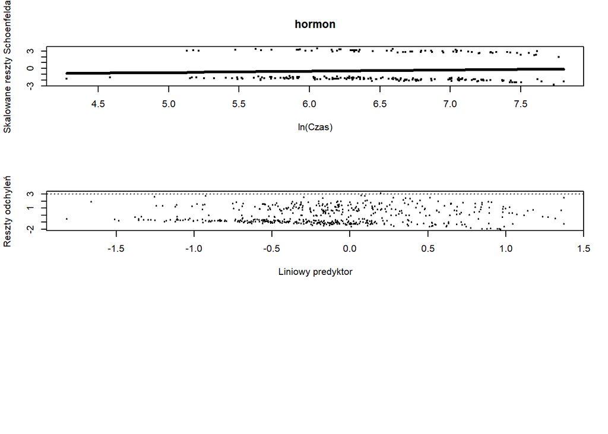

```r
deviance=residuals(Cox3,type="deviance")
s=Cox3$linear.predictors
plot(s,deviance,xlab="Liniowy predyktor",ylab="Reszty odchyleń",cex=0.5, pch=20)

abline(h=3,lty=3)
dane$deviance <- deviance
c1 <- which(dane$deviance > 3)
```

## 4.13 - Usuwanie ze zbioru jednostek odstających dla modelu Cox3

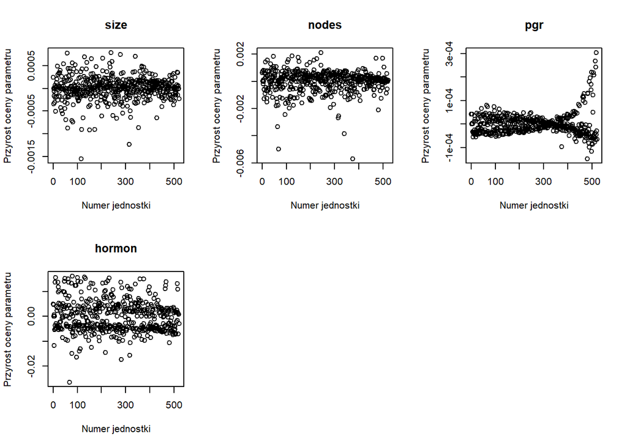

```r
dfb=residuals(Cox3,type="dfbeta")
n=dim(dfb)[1]
obs.nr=c(1:n)
par(mfrow = c(2,3))
for (j in 1:4) {
  plot(obs.nr,dfb[,j],xlab="Numer jednostki",ylab="Przyrost oceny parametru",
      main=zmienne[j])
  }
a1 = which(abs(dfb[,1])>(0.004)) #usunac te jednostki
a2 = which(abs(dfb[,2])>(0.06))
a3 = which(abs(dfb[,3])>(0.001))
a4 = which(abs(dfb[,4])>(0.004))

c <- sort(unique(c(a1,a2,a3,a4,c1)))
danec2 <- dane[-c,]
```

## 4.14 - Identyfikacja jednostek odstających Cox4

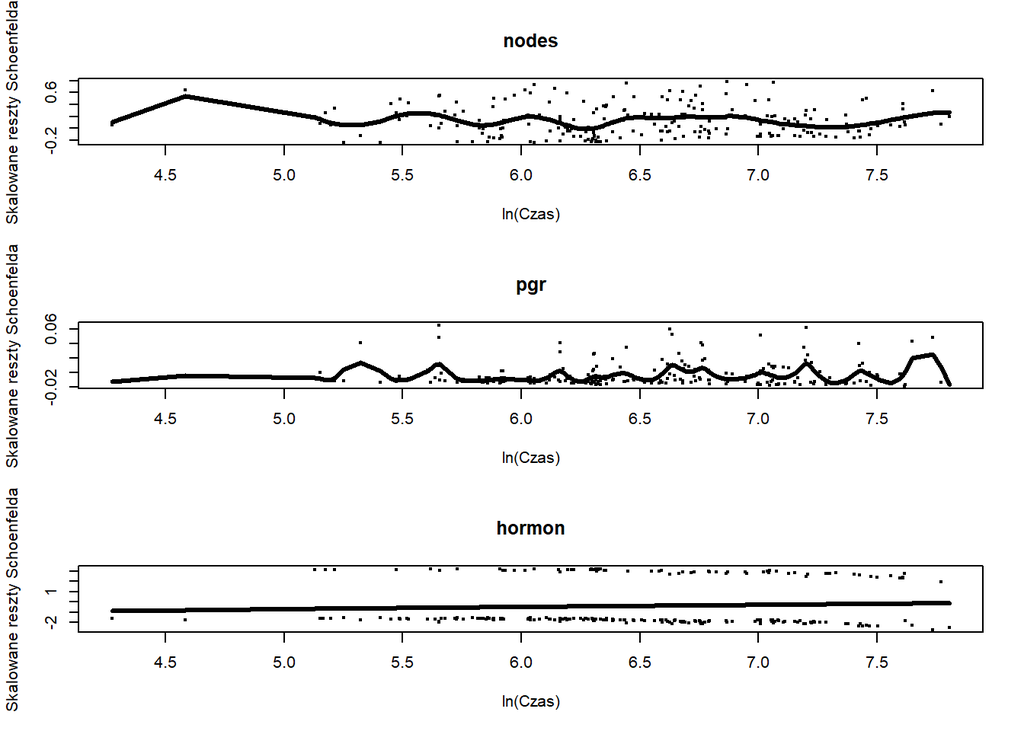

```r
reszty <- resid(Cox4, type="scaledsch")
Time <- as.numeric(rownames(reszty))
zmienne <- names(dane[,c(6,7,9)])

par(mfrow = c(3,1))
for (i in 1:3) {
  plot(log(Time), reszty[,i], xlab="ln(Czas)", main=zmienne[i],
       ylab="Skalowane reszty Schoenfelda", pch=20, cex=0.7)
  lines(smooth.spline(log(Time), reszty[,i] ), lwd=3 )
}
```

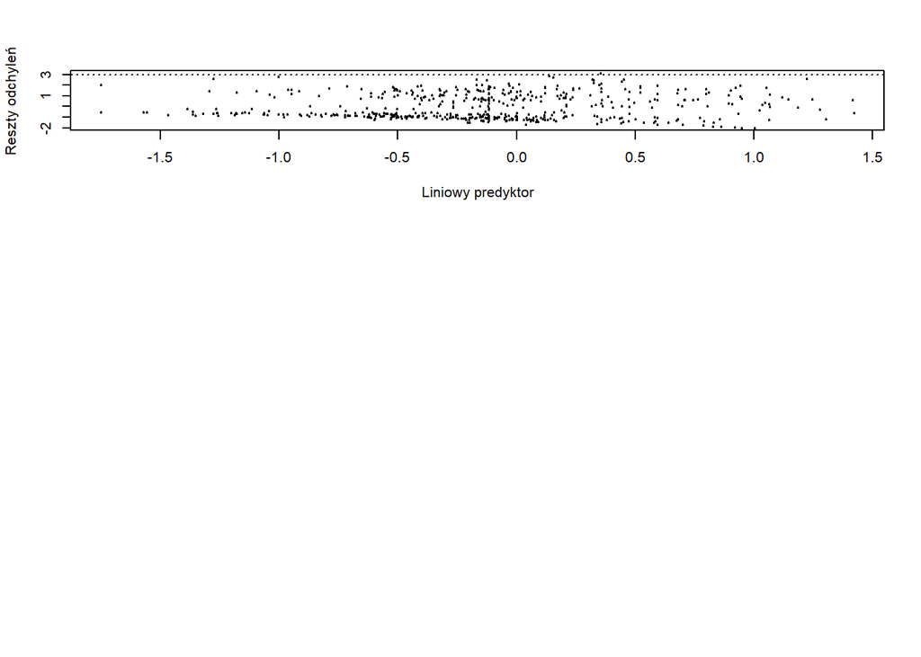

```r
deviance=residuals(Cox4,type="deviance")
s=Cox4$linear.predictors
plot(s,deviance,xlab="Liniowy predyktor",ylab="Reszty odchyleń",cex=0.5, pch=20)

abline(h=3,lty=3)
dane$deviance <- deviance
c1 <- which(dane$deviance > 3)
```

## 4.15 - Usuwanie ze zbioru jednostek odstających dla modelu Cox4

Jednostki, które są odbiegające od reszty i wpływowe powinny, w miarę możliwości, zostać usunięte z badanej próby.

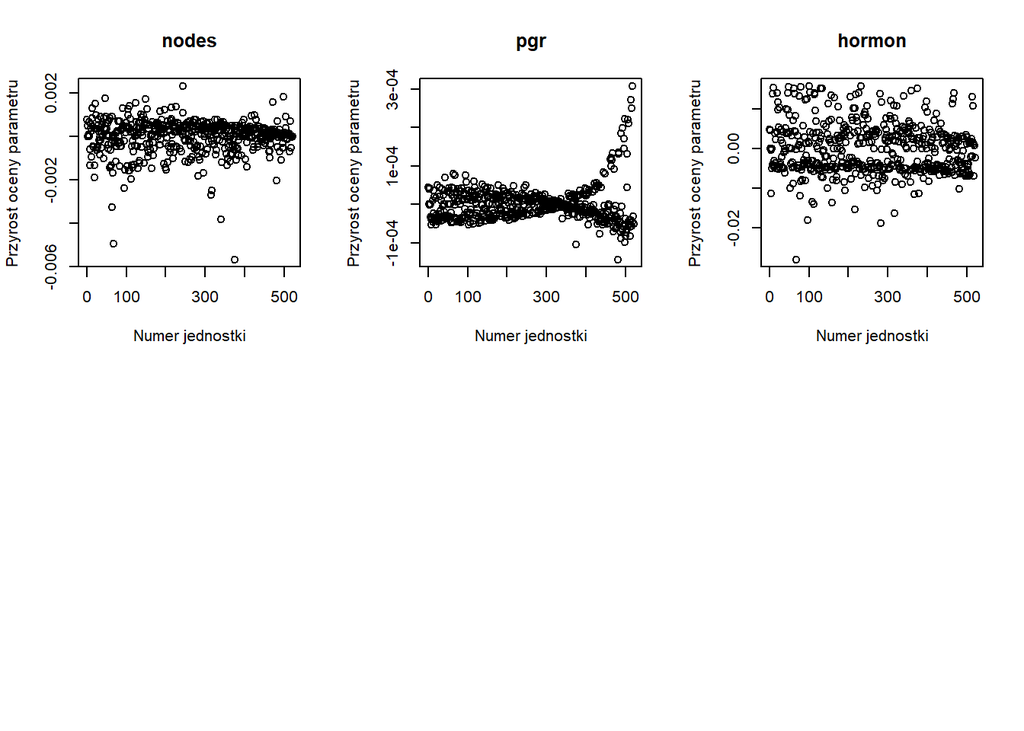

```r
dfb=residuals(Cox4,type="dfbeta")
n=dim(dfb)[1]
obs.nr=c(1:n)
par(mfrow = c(2,3))
for (j in 1:3) {
  plot(obs.nr,dfb[,j],xlab="Numer jednostki",ylab="Przyrost oceny parametru",
      main=zmienne[j])
  }
a1 = which(abs(dfb[,1])>(0.001)) #usunac te jednostki
a2 = which(abs(dfb[,2])>(0.006))
a3 = which(abs(dfb[,3])>(0.0045))

c <- sort(unique(c(a1,a2,a3,c1)))
danec3 <- dane[-c,]
```

## 4.16 - Oszacowanie modeli na zredukowanych zbiorach

### 4.16.1 - Model PH Cox5

**Interpretacja parametrów modelu PH Cox5:**

- Zmienna grade przestała być istotna (p-value > 0.05). Zrezygnowano z brania pod uwagę tego modelu.

```r
Cox5 <- coxph(Surv(rfstime,cens)~grade+nodes+pgr+hormon, data = danec1)
summary(Cox5)
```

```
## Call:
## coxph(formula = Surv(rfstime, cens) ~ grade + nodes + pgr + hormon,
##     data = danec1)
##
##   n= 252, number of events= 104
##
##               coef  exp(coef)   se(coef)      z Pr(>|z|)
## grade2   1.096e+01  5.741e+04  2.617e+03  0.004 0.996659
## grade3   1.063e+01  4.152e+04  2.617e+03  0.004 0.996758
## nodes    1.971e-01  1.218e+00  2.572e-02  7.663 1.82e-14 ***
## pgr     -1.670e-02  9.834e-01  4.712e-03 -3.544 0.000394 ***
## hormon1 -5.569e-01  5.730e-01  2.268e-01 -2.455 0.014079 *
## ---
## Signif. codes:  0 '***' 0.001 '**' 0.01 '*' 0.05 '.' 0.1 ' ' 1
##
##         exp(coef) exp(-coef) lower .95 upper .95
## grade2  5.741e+04  1.742e-05    0.0000       Inf
## grade3  4.152e+04  2.409e-05    0.0000       Inf
## nodes   1.218e+00  8.211e-01    1.1580    1.2808
## pgr     9.834e-01  1.017e+00    0.9744    0.9926
## hormon1 5.730e-01  1.745e+00    0.3673    0.8937
##
## Concordance= 0.792  (se = 0.018 )
## Likelihood ratio test= 85.74  on 5 df,   p=<2e-16
## Wald test            = 85.3  on 5 df,   p=<2e-16
## Score (logrank) test = 93.96  on 5 df,   p=<2e-16
```

### 4.16.2 - Model PH Cox6

**Interpretacja parametrów modelu PH Cox6:**

*Hazard określany jest jako ryzyko zgonu pod warunkiem, że jednostka dożyje do danego momentu.*

- Jeżeli wielkość guza wzrośnie o 1mm, hazard wzrośnie o 6,6%, cp.
- Jeżeli liczba węzłów chłonnych z przerzutami wzrośnie o 1, to hazard wrośnie o 38,3%, cp.
- Jeżeli poziom receptorów progesteronowych wzrośnie o 1 (fmol/l) to hazard zmaleje o 1,47%, cp.
- Pacjentki, które przechodzą terapię hormonalną mają hazard o 72,61% niższy niż pacjentki, które nie przechodzą terapii hormonalnej, cp.

```r
Cox6 <- coxph(Surv(rfstime,cens)~size+nodes+pgr+hormon, data = danec2)
summary(Cox6)
```

```
## Call:
## coxph(formula = Surv(rfstime, cens) ~ size + nodes + pgr + hormon,
##     data = danec2)
##
##   n= 220, number of events= 57
##
##              coef exp(coef)  se(coef)      z Pr(>|z|)
## size     0.063952  1.066041  0.011798  5.420 5.94e-08 ***
## nodes    0.324259  1.383005  0.038014  8.530  < 2e-16 ***
## pgr     -0.014818  0.985291  0.003395 -4.365 1.27e-05 ***
## hormon1 -1.294961  0.273908  0.492069 -2.632   0.0085 **
## ---
## Signif. codes:  0 '***' 0.001 '**' 0.01 '*' 0.05 '.' 0.1 ' ' 1
##
##         exp(coef) exp(-coef) lower .95 upper .95
## size       1.0660     0.9381    1.0417    1.0910
## nodes      1.3830     0.7231    1.2837    1.4900
## pgr        0.9853     1.0149    0.9788    0.9919
## hormon1    0.2739     3.6509    0.1044    0.7185
##
## Concordance= 0.924  (se = 0.011 )
## Likelihood ratio test= 156.5  on 4 df,   p=<2e-16
## Wald test            = 104  on 4 df,   p=<2e-16
## Score (logrank) test = 180.8  on 4 df,   p=<2e-16
```

### 4.16.3 - Model PH Cox7

**Interpretacja parametrów modelu PH Cox7:**

*Hazard określany jest jako ryzyko zgonu pod warunkiem, że jednostka dożyje do danego momentu.*

- Jeżeli liczba węzłów chłonnych z przerzutami wzrośnie o 1, hazard wrośnie o 39,4%, cp.
- Jeżeli poziom receptorów progesteronowych wzrośnie o 1 (fmol/l) to hazard zmaleje o 1,43%, cp.
- Pacjentki, które przechodzą terapię hormonalną mają hazard o 57,33% niższy niż pacjentki, które nie przechodzą terapii hormonalnej, cp.

```r
Cox7 <- coxph(Surv(rfstime,cens)~ nodes+pgr+hormon, data = danec3)
summary(Cox7)
```

```
## Call:
## coxph(formula = Surv(rfstime, cens) ~ nodes + pgr + hormon, data = danec3)
##
##   n= 243, number of events= 64
##
##              coef exp(coef)  se(coef)      z Pr(>|z|)
## nodes    0.332188  1.394015  0.035914  9.250  < 2e-16 ***
## pgr     -0.014382  0.985721  0.002937 -4.896 9.76e-07 ***
## hormon1 -0.851556  0.426750  0.418339 -2.036   0.0418 *
## ---
## Signif. codes:  0 '***' 0.001 '**' 0.01 '*' 0.05 '.' 0.1 ' ' 1
##
##         exp(coef) exp(-coef) lower .95 upper .95
## nodes      1.3940     0.7174    1.2993    1.4957
## pgr        0.9857     1.0145    0.9801    0.9914
## hormon1    0.4268     2.3433    0.1880    0.9689
##
## Concordance= 0.873  (se = 0.016 )
## Likelihood ratio test= 124.3  on 3 df,   p=<2e-16
## Wald test            = 99.7  on 3 df,   p=<2e-16
## Score (logrank) test = 148.5  on 3 df,   p=<2e-16
```

## 4.17 - Metoda reszt martyngałowych

Metoda reszt martyngałowych polega na wyznaczeniu reszt martyngałowych dla zmiennych objaśniających ilościowych. Rozrzut reszt martyngałowych pokazuje kształt związku łączącego zmienną objaśniającą z logarytmem hazardu. Jeżeli funkcja ta ma kształt zbliżony do liniowego to potwierdza to liniowość relacji między zmienną objaśniającą a logarytmem hazardu, w przeciwnym wypadku kształt funkcji może być wskazówką co do wyboru odpowiedniej metody transformacji zmiennej.

### 4.17.1 - Reszty martyngałowe dla zmiennych ilościowych z modelu Cox6

- **size** - Potwierdzenie założenia o liniowości
- **nodes** - Potwierdzenie założenia o liniowości
- **pgr** - Potwierdzenie założenia o liniowości

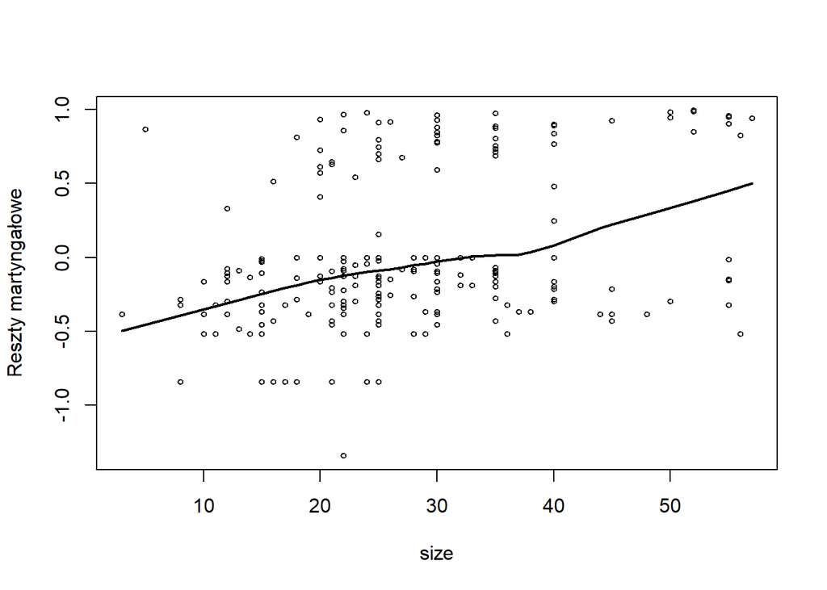

```r
zmn8 <- danec2$size
lab8 <- "size"
reszty8 <- resid(coxph(Surv(rfstime,cens)~1,data=danec2),type="martingale")
plot(zmn8, reszty8, xlab=lab8,ylab="Reszty martyngałowe",cex=0.6)
lines(lowess(zmn8, reszty8,delta=1),lwd=2)
```

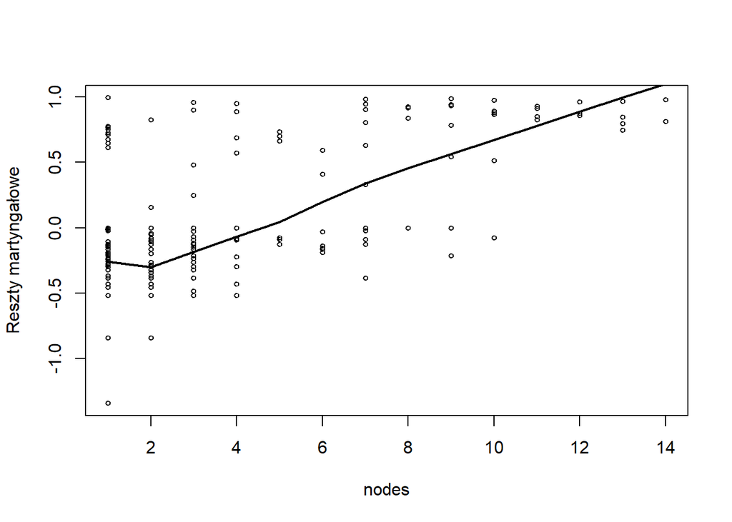

```r
zmn9 <- danec2$nodes
lab9 <- "nodes"
reszty9 <- resid(coxph(Surv(rfstime,cens)~1,data=danec2),type="martingale")
plot(zmn9, reszty9, xlab=lab9,ylab="Reszty martyngałowe",cex=0.6)
lines(lowess(zmn9, reszty9,delta=1),lwd=2)
```

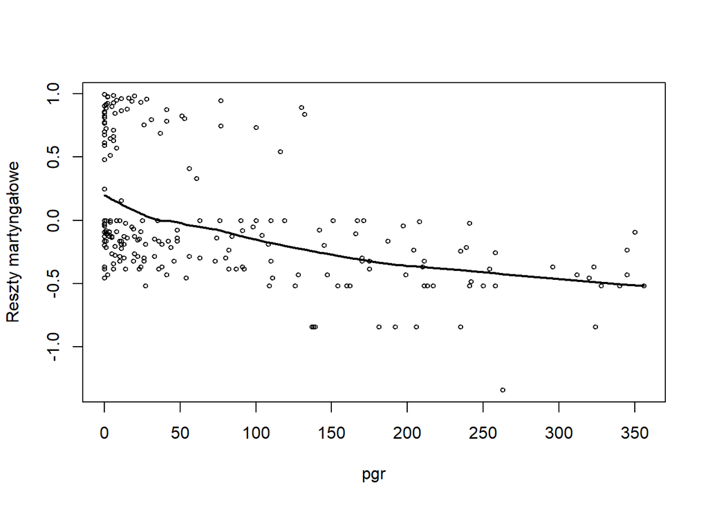

```r
zmn10 <- danec2$pgr
lab10 <- "pgr"
reszty10 <- resid(coxph(Surv(rfstime,cens)~1,data=danec2),type="martingale")
plot(zmn10, reszty10, xlab=lab10,ylab="Reszty martyngałowe",cex=0.6)
lines(lowess(zmn10, reszty10,delta=1),lwd=2)
```

### 4.17.2 - Reszty martyngałowe dla zmiennych ilościowych z modelu Cox7

- **nodes** - Potwierdzenie założenia o liniowości
- **pgr** - Potwierdzenie założenia o liniowości

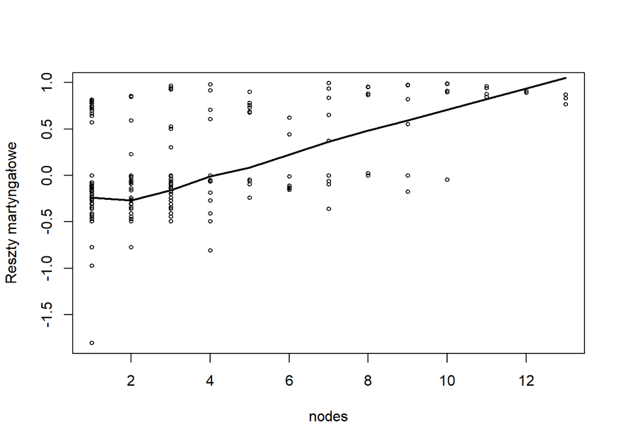

```r
zmn9 <- danec3$nodes
lab9 <- "nodes"
reszty9 <- resid(coxph(Surv(rfstime,cens)~1,data=danec3),type="martingale")
plot(zmn9, reszty9, xlab=lab9,ylab="Reszty martyngałowe",cex=0.6)
lines(lowess(zmn9, reszty9,delta=1),lwd=2)
```

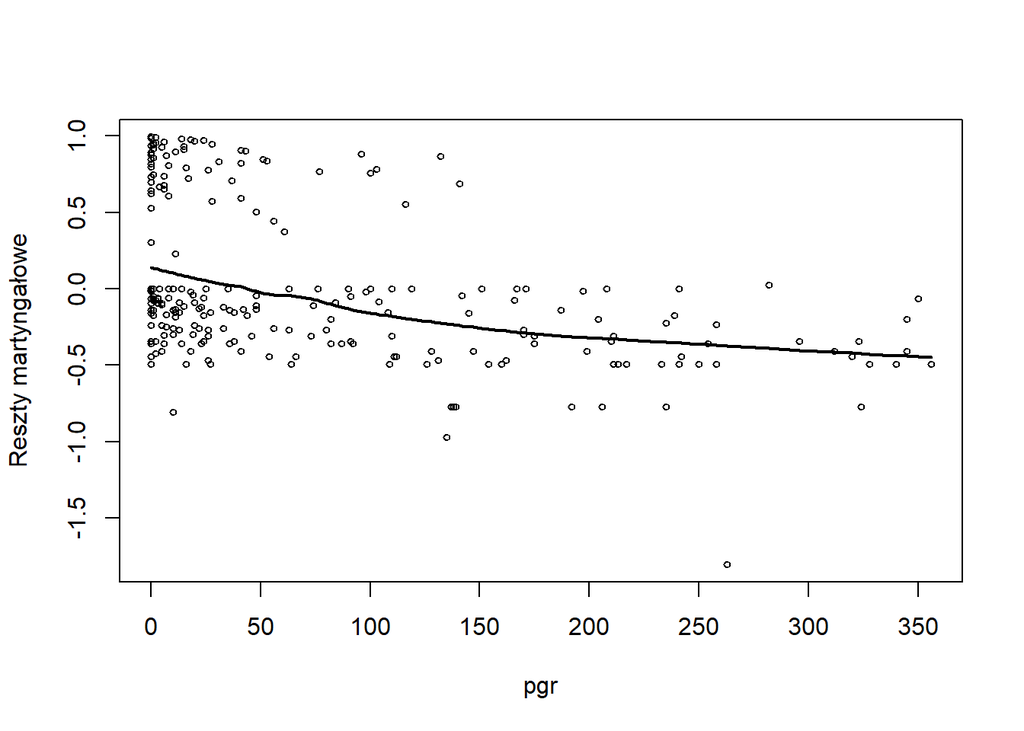

```r
zmn10 <- danec3$pgr
lab10 <- "pgr"
reszty10 <- resid(coxph(Surv(rfstime,cens)~1,data=danec3),type="martingale")
plot(zmn10, reszty10, xlab=lab10,ylab="Reszty martyngałowe",cex=0.6)
lines(lowess(zmn10, reszty10,delta=1),lwd=2)
```

W celu porównania modeli zwierajacych różne zestawy zmiennych objaśniających, wykorzystano kryterium informacyjne Akaike. Na podstawie kryterium najelpszy okazał się model Cox6 i Cox7.

```r
AIC_Cox1 <- AIC(Cox1)
AIC_Cox2 <- AIC(Cox2)
AIC_Cox3 <- AIC(Cox3)
AIC_Cox4 <- AIC(Cox4)
AIC_Cox5 <- AIC(Cox5)
AIC_Cox6 <- AIC(Cox6)
AIC_Cox7 <- AIC(Cox7)
round(rbind(AIC_Cox1, AIC_Cox2, AIC_Cox3, AIC_Cox4, AIC_Cox5, AIC_Cox6, AIC_Cox7),2)
```

```
##             [,1]
## AIC_Cox1 2488.71
## AIC_Cox2 2483.39
## AIC_Cox3 2487.17
## AIC_Cox4 2486.89
## AIC_Cox5  888.05
## AIC_Cox6  366.84
## AIC_Cox7  463.47
```

## 4.19 - Miary dopasowania R2 dla wszystkich 7 modeli

Miary dopasowania R2 zostały obliczone na podstawie statystyki cząstkowej ilorazu wiarygodności w modelu Coxa. Interpretację podano tylko dla modeli Cox5, Cox6 oraz Cox7. * Najlepiej dopasowanym modelem, który posiada wartość dopasowania **R2 = 0,94** jest model Cox6, otrzymany po odrzuceniu zmiennych niespełniajacych założeń proporcjonalnosci oraz wyeliminowaniu jednostek odstających i wpływowych.

```r
mr1 <- coxr2(Cox1)
mr2 <- coxr2(Cox2)
mr3 <- coxr2(Cox3)
mr4 <- coxr2(Cox4)
mr5 <- coxr2(Cox5) #top3
mr6 <- coxr2(Cox6) #top1
mr7 <- coxr2(Cox7) #top2
round(rbind(mr1$rsq, mr2$rsq, mr3$rsq, mr4$rsq, mr5$rsq, mr6$rsq, mr7$rsq),2)
```

```
##       rsq
## [1,] 0.29
## [2,] 0.28
## [3,] 0.26
## [4,] 0.26
## [5,] 0.56
## [6,] 0.94
## [7,] 0.86
```